# NYPD Shooting Incident Data

2023-04-16

## Information on Data and Background of Project

- **Incident Key (INCIDENT_KEY):** The specific identification code for the shooting incident that occurred and filed in the NYPD system.
- **Occur Date (OCCUR_DATE):** The date the shooting incident occurred.
- **Boroughs (BORO):** The borough where the shooting incident occurred (Brooklyn, Queens, Bronx, Manhattan, Staten Island).
- **Precinct (PRECINCT):** The specific police precinct number where the shooting incident occurred.
- **Jurisdiction Code (JURISDICTION_CODE):** The specific number used to define the jurisdiction code in which the shooting incident is categorized.
- **Description of the Location (LOCATION_DESC):** A generalized location for where the shooting incident occurred.
- **Murder vs. Non-Murder (STATISTICAL_MURDER_FLAG):** Boolean True/False indicating whether the shooting incident was classified as a Murder.
- **Perpetrator Age Group (PERP_AGE_GROUP):** The age group of the perpetrator (<18, 18-25. 25-44, 45-64, 65+, Unknown, NA).
- **Perpetrator Sex (PERP_SEX):** The sex of the perpetrator.
- **Perpetrator Race (PERP_RACE):** The race of the perpetrator.
- **Victim Age Group (VIC_AGE_GROUP):** The age group of the victim (<18, 18-25. 25-44, 45-64, 65+, Unknown).
- **Victim Sex (VIC_SEX):** The sex of the victim.
- **Victim Race (VIC_RACE):** The race of the victim.
- **X Coordinate (X_COORD_CD):** The X coordinate for where the shooting incident occurred.
- **Y Coordinate (Y_COORD_CD):** The Y coordinate for where the shooting incident occurred.
- **Latitude (Latitude):** The longitude for where the shooting incident occurred.
- **Longitude (Longitude):** The latitude for where the shooting incident occurred.
- **Longitude/Latitude (Lon_Lat):** Combined longitude and latitude point where the shooting incident occurred.

## Tidy and Transform the Data:

The first step in this project is to tidy and transform the data to prepare it for visualization and analysis. The following libraries were imported to help with this project:

- Tidyverse
- Leaflet (including Leaflet Extras)
- Corrplot

```r
library(tidyverse) #ggplot, tidy, etc. functions
library(leaflet) #NYC map visual + heatmap
library(leaflet.extras) #used for heatmap
library(corrplot) #correlation plot analysis
```

The data was pulled from the CSV file from Data.gov. The link to the CSV file was saved as `url` and using `read_csv()` the data was transferred to the dataframe titled `nypd_df`.

```r
url <- 'https://data.cityofnewyork.us/api/views/833y-fsy8/rows.csv?accessType=DOWNLOAD'
nypd_df <- read_csv(url)
summary(nypd_df)
```

```
##   INCIDENT_KEY        OCCUR_DATE         OCCUR_TIME           BORO
##  Min.   :  9953245   Length:27312       Length:27312      Length:27312
##  1st Qu.: 63860880   Class :character   Class1:hms        Class :character
##  Median : 90372218   Mode  :character   Class2:difftime   Mode  :character
##  Mean   :120860536                      Mode  :numeric
##  3rd Qu.:188810230
##  Max.   :261190187
##
##  LOC_OF_OCCUR_DESC     PRECINCT      JURISDICTION_CODE LOC_CLASSFCTN_DESC
##  Length:27312       Min.   :  1.00   Min.   :0.0000    Length:27312
##  Class :character   1st Qu.: 44.00   1st Qu.:0.0000    Class :character
##  Mode  :character   Median : 68.00   Median :0.0000    Mode  :character
##                     Mean   : 65.64   Mean   :0.3269
##                     3rd Qu.: 81.00   3rd Qu.:0.0000
##                     Max.   :123.00   Max.   :2.0000
##                                      NA's   :2
##  LOCATION_DESC      STATISTICAL_MURDER_FLAG PERP_AGE_GROUP
##  Length:27312       Mode :logical           Length:27312
##  Class :character   FALSE:22046             Class :character
##  Mode  :character   TRUE :5266              Mode  :character
##
##
##
##
##    PERP_SEX          PERP_RACE         VIC_AGE_GROUP        VIC_SEX
##  Length:27312       Length:27312       Length:27312       Length:27312
##  Class :character   Class :character   Class :character   Class :character
##  Mode  :character   Mode  :character   Mode  :character   Mode  :character
##
##
##
##
##    VIC_RACE           X_COORD_CD        Y_COORD_CD        Latitude
##  Length:27312       Min.   : 914928   Min.   :125757   Min.   :40.51
##  Class :character   1st Qu.:1000028   1st Qu.:182834   1st Qu.:40.67
##  Mode  :character   Median :1007731   Median :194487   Median :40.70
##                     Mean   :1009449   Mean   :208127   Mean   :40.74
##                     3rd Qu.:1016838   3rd Qu.:239518   3rd Qu.:40.82
##                     Max.   :1066815   Max.   :271128   Max.   :40.91
##                                                        NA's   :10
##    Longitude        Lon_Lat
##  Min.   :-74.25   Length:27312
##  1st Qu.:-73.94   Class :character
##  Median :-73.92   Mode  :character
##  Mean   :-73.91
##  3rd Qu.:-73.88
##  Max.   :-73.70
##  NA's   :10
```

The date, `OCCUR_DATE`, was converted to a date, and the time count, `OCCUR_TIME`, was changed to a time using the Lubridate library.

```r
nypd_df <- nypd_df %>%
  mutate(OCCUR_TIME = hms(OCCUR_TIME),
         OCCUR_DATE = mdy(OCCUR_DATE)) %>%
  mutate(Year = year(OCCUR_DATE),
         Month = month(OCCUR_DATE),
         Day = wday(OCCUR_DATE, label = TRUE),
         Hour_Of_Day = hour(OCCUR_TIME))
nypd_df
```

```
## # A tibble: 27,312 × 25
##    INCIDENT_KEY OCCUR_DATE OCCUR_TIME BORO     LOC_OF_OCCUR_DESC PRECINCT
##           <dbl> <date>     <Period>   <chr>    <chr>                <dbl>
##  1    228798151 2021-05-27 21H 30M 0S QUEENS   <NA>                   105
##  2    137471050 2014-06-27 17H 40M 0S BRONX    <NA>                    40
##  3    147998800 2015-11-21 3H 56M 0S  QUEENS   <NA>                   108
##  4    146837977 2015-10-09 18H 30M 0S BRONX    <NA>                    44
##  5     58921844 2009-02-19 22H 58M 0S BRONX    <NA>                    47
##  6    219559682 2020-10-21 21H 36M 0S BROOKLYN <NA>                    81
##  7     85295722 2012-06-17 22H 47M 0S QUEENS   <NA>                   114
##  8     71662474 2010-03-08 19H 41M 0S BROOKLYN <NA>                    81
##  9     83002139 2012-02-05 5H 45M 0S  QUEENS   <NA>                   105
## 10     86437261 2012-08-26 1H 10M 0S  QUEENS   <NA>                   101
## # ℹ 27,302 more rows
## # ℹ 19 more variables: JURISDICTION_CODE <dbl>, LOC_CLASSFCTN_DESC <chr>,
## #   LOCATION_DESC <chr>, STATISTICAL_MURDER_FLAG <lgl>, PERP_AGE_GROUP <chr>,
## #   PERP_SEX <chr>, PERP_RACE <chr>, VIC_AGE_GROUP <chr>, VIC_SEX <chr>,
## #   VIC_RACE <chr>, X_COORD_CD <dbl>, Y_COORD_CD <dbl>, Latitude <dbl>,
## #   Longitude <dbl>, Lon_Lat <chr>, Year <dbl>, Month <dbl>, Day <ord>,
## #   Hour_Of_Day <dbl>
```

To later analyze how each Borough in NYC is impacted by these shooting incidents, the population of each Borough in NYC is needed so that the number of incidents is not exaggerated in high-population areas or reduced in low-population areas. To analyze this, census data from New York was downloaded into a csv file and saved to `url_census_info`. Using the `read_csv` function, this data was saved to a dataframe, titled `census_data` The data included the total population by borough.

Since this file was saved as a csv on my personal computer, the creation of url_census_info was hidden. The link to the website where the information was obtained is: https://data.cityofnewyork.us/City-Government/New-York-City-Population-by-Borough-1950-2040/xywu-7bv9

```r
census_data <- read_csv(url_census_info)
summary(census_data)
```

```
##   Age Group           Borough               1950
##  Length:6           Length:6           Min.   : 191555
##  Class :character   Class :character   1st Qu.:1476170
##  Mode  :character   Mode  :character   Median :1755475
##                                        Mean   :2630652
##                                        3rd Qu.:2543656
##                                        Max.   :7891957
##  1950 - Boro share of NYC total      1960
##  Min.   :  2.43                 Min.   : 221991
##  1st Qu.: 18.70                 1st Qu.:1493182
##  Median : 22.25                 Median :1753930
##  Mean   : 33.34                 Mean   :2593995
##  3rd Qu.: 32.23                 3rd Qu.:2422884
##  Max.   :100.00                 Max.   :7781984
##  1960 - Boro share of NYC total      1970
##  Min.   :  2.85                 Min.   : 295443
##  1st Qu.: 19.19                 1st Qu.:1488584
##  Median : 22.54                 Median :1762853
##  Mean   : 33.33                 Mean   :2631621
##  3rd Qu.: 31.13                 3rd Qu.:2448127
##  Max.   :100.00                 Max.   :7894862
##  1970 - Boro share of NYC total      1980
##  Min.   :  3.74                 Min.   : 352121
##  1st Qu.: 18.86                 1st Qu.:1233800
##  Median : 22.33                 Median :1659805
##  Mean   : 33.33                 Mean   :2357213
##  3rd Qu.: 31.01                 3rd Qu.:2146033
##  Max.   :100.00                 Max.   :7071639
##  1980 - Boro share of NYC total      1990
##  Min.   :  4.98                 Min.   : 378977
##  1st Qu.: 17.45                 1st Qu.:1274726
##  Median : 23.48                 Median :1719567
##  Mean   : 33.34                 Mean   :2440855
##  3rd Qu.: 30.35                 3rd Qu.:2213398
##  Max.   :100.00                 Max.   :7322564
##  1990 - Boro share of NYC total      2000
##  Min.   :  5.18                 Min.   : 443728
##  1st Qu.: 17.41                 1st Qu.:1383786
##  Median : 23.48                 Median :1883287
##  Mean   : 33.33                 Mean   :2669426
```

[output cut: 22 more lines]

```
##  Max.   :100.00                 Max.   :8821027
##  2030 - Boro share of NYC total      2040
##  Min.   :  5.64                 Min.   : 501109
##  1st Qu.: 17.67                 1st Qu.:1607338
##  Median : 22.96                 Median :2052133
##  Mean   : 33.33                 Mean   :3008382
##  3rd Qu.: 30.14                 3rd Qu.:2733556
##  Max.   :100.00                 Max.   :9025145
##  2040 - Boro share of NYC total
##  Min.   :  5.55
##  1st Qu.: 17.81
##  Median : 22.73
##  Mean   : 33.33
##  3rd Qu.: 30.29
##  Max.   :100.00
```

The census data was then further cleaned so that it could be merged into `nypd_df` The cleaning process included:

- Removing some of the years and population data that are not in the scope of this project.
- Renaming Borough to match BORO in `nypd_df`
- Renaming all of the individual Boroughs to match in `nypd_df`

```r
census_data <- census_data[, c('2000', '2010', '2020', '2030', 'Borough')] # removing all of the years of statistics outside of the scope of the NYPD Shooting data.
colnames(census_data)[5] = "BORO" #rename column to match BORO from the other nypd_df for later merge
new_census_data <- gather(census_data, key = "Year", value = "Population", -BORO) #rearrange all years into one column and all populations into one column
new_census_data <- new_census_data %>% # rename all of the boroughs to match the nypd_df dataframe
  mutate(BORO = if_else(BORO == "Bronx", "BRONX", BORO)) %>%
  mutate(BORO = if_else(BORO == "Brooklyn", "BROOKLYN", BORO)) %>%
  mutate(BORO = if_else(BORO == "Manhattan", "MANHATTAN", BORO)) %>%
  mutate(BORO = if_else(BORO == "Queens", "QUEENS", BORO)) %>%
  mutate(BORO = if_else(BORO == "Staten Island", "STATEN ISLAND", BORO))
new_census_data
```

```
## # A tibble: 24 × 3
##    BORO          Year  Population
##    <chr>         <chr>      <dbl>
##  1 NYC Total     2000     8008278
##  2 BRONX         2000     1332650
##  3 BROOKLYN      2000     2465326
##  4 MANHATTAN     2000     1537195
##  5 QUEENS        2000     2229379
##  6 STATEN ISLAND 2000      443728
##  7 NYC Total     2010     8242624
##  8 BRONX         2010     1385108
##  9 BROOKLYN      2010     2552911
## 10 MANHATTAN     2010     1585873
## # ℹ 14 more rows
```

The population analysis specifically will look at each borough in NYC; therefore a new dataframe was made to include the count of incidents and the year. This was then later merged with the population dataframe to create the `ny_boro_and_pop` dataframe that contains Borough, Year, Population, and Shooting Incident Count.

Additional dataframes were made for analyzing when these shooting incidents occur, based on the month of the year and time of day. These dataframes were created here for later visualizations as well.

```r
nypd_by_boro <- nypd_df %>%
  count(BORO, Year, sort = TRUE) #create a new dataframe containing Borough name, Year, and number of incidents

nypd_by_year <- nypd_df %>%
  count(Year, Month, sort = TRUE) #create a new dataframe that contains year, month, and number of incidents.

nypd_by_hour <- nypd_df %>% #create a new dataframe that contains day, the hour of day, and number of incidents.
  count(Day, Hour_Of_Day, sort = TRUE)
```

```r
ny_boro_and_pop <- merge(nypd_by_boro, new_census_data, by="BORO") # merge
ny_boro_and_pop$Year.y <- as.numeric(as.character(ny_boro_and_pop$Year.y))
```

## Visualizations and Analysis:

### What borough in NYC has the most shooting incidents?

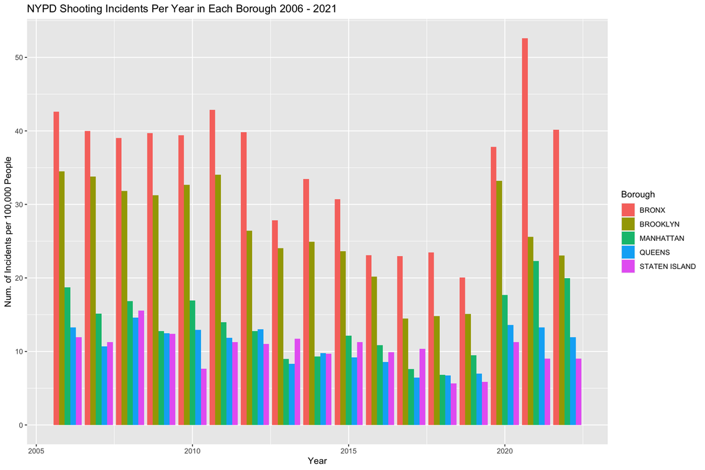

```r
ggplot(ny_boro_and_pop) +
  geom_bar(aes(x = Year.x,
               y = n/(Population/100000),
               fill = factor(BORO)),
           stat = "identity",
           position = "dodge") +
  labs(title = "NYPD Shooting Incidents Per Year in Each Borough 2006 - 2021",
       x = "Year",
       y = "Num. of Incidents per 100,000 People",
       fill = "Borough")
```

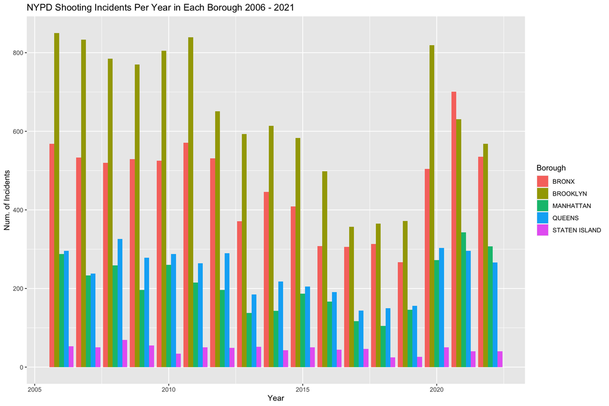

```r
ggplot(ny_boro_and_pop) +
  geom_bar(aes(x = Year.x,
               y = n,
               fill = factor(BORO)),
           stat = "identity",
           position = "dodge") +
  labs(title = "NYPD Shooting Incidents Per Year in Each Borough 2006 - 2021",
       x = "Year",
       y = "Num. of Incidents",
       fill = "Borough")
```

```r
nypd_df <- nypd_df[!is.na(nypd_df$Latitude), ] #remove NA specifically from the Latitude column
nypd_df <- nypd_df[!is.na(nypd_df$Longitude), ] #remove NA specifically from the Longitude column
nypd_df %>%
  leaflet() %>%
  addTiles()%>%
  fitBounds(max(nypd_df$Longitude),
            min(nypd_df$Latitude),
            min(nypd_df$Longitude),
            max(nypd_df$Latitude)) %>%
  addHeatmap(lng=nypd_df$Longitude,
             lat=nypd_df$Latitude,
             blur=30,
             radius=15)
```

[interactive chart not shown]

### When are these shooting incidents happening?:

The next set of visualizations looks at when these shooting events are occurring in NYC; specifically, the month of the year and the time of the day.

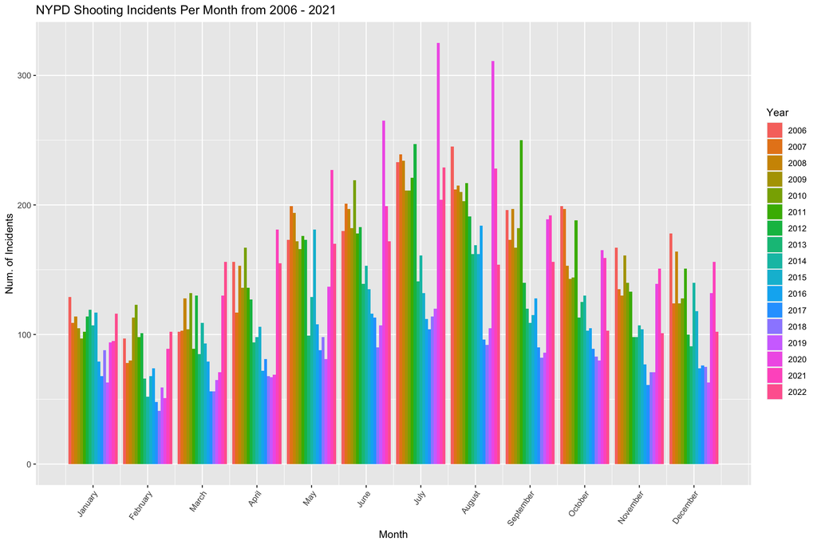

```r
ggplot(nypd_by_year, aes(x = Month, y = n, fill=factor(Year))) +
  geom_bar(stat = "identity", position = "dodge") +
  scale_x_continuous(breaks = seq_along(month.name),
                     labels=month.name) +
  theme(axis.text.x = element_text(angle = 55, hjust = 1)) +
  labs(title = "NYPD Shooting Incidents Per Month from 2006 - 2021",
       x = "Month",
       y = "Num. of Incidents",
       fill = "Year")
```

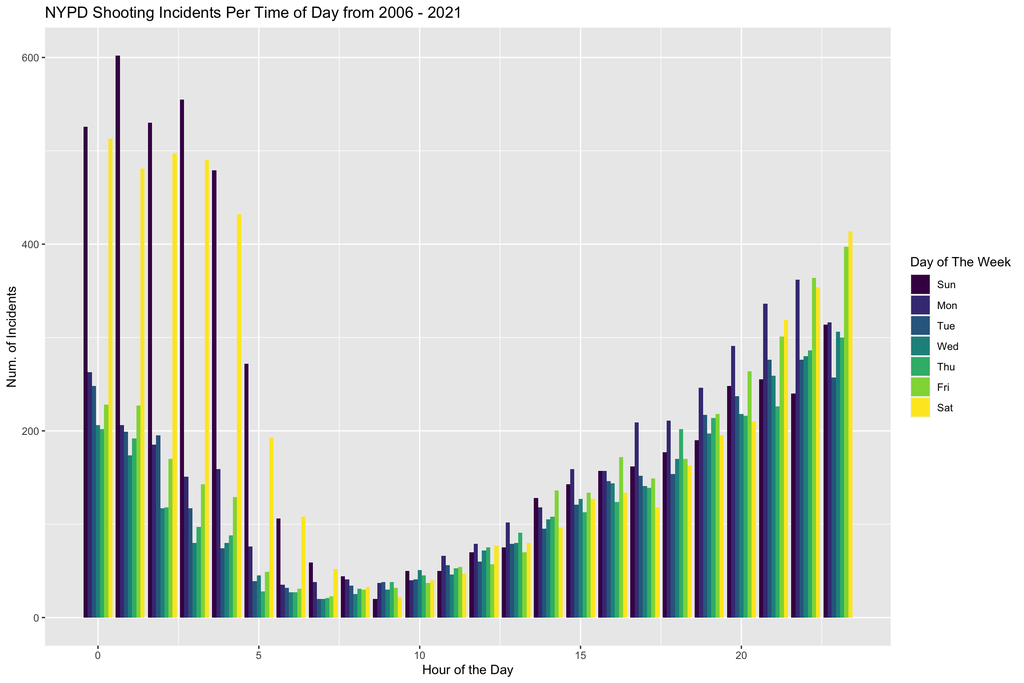

```r
ggplot(nypd_by_hour, aes(x = Hour_Of_Day, y = n, fill=factor(Day))) +
  geom_bar(stat = "identity", position = "dodge") +
  labs(title = "NYPD Shooting Incidents Per Time of Day from 2006 - 2021",
       x = "Hour of the Day",
       y = "Num. of Incidents",
       fill = "Day of The Week")
```

### How do the variables in the data correlate?:

Several variables were examined via a correlation plot and heatmap to understand which models will potentially be successful using linear regression modeling. These variables include:

- Borough
- Statistical Murder Flag
- Perpetrator Age Group, Sex, and Race
- Victim Age Group, Sex, and Race

To examine this information, the `nypd_corr` dataframe was created. All ‘NA’ values were omitted and all of the variables were factored and made numeric. The names of the dataframe were changed to allow for a cleaner visualization. The dataframe was turned into a correlation matrix via the `cor()` function. This matrix was then visualized via a heatmap and a correlation plot (created with the use of Corrplot).

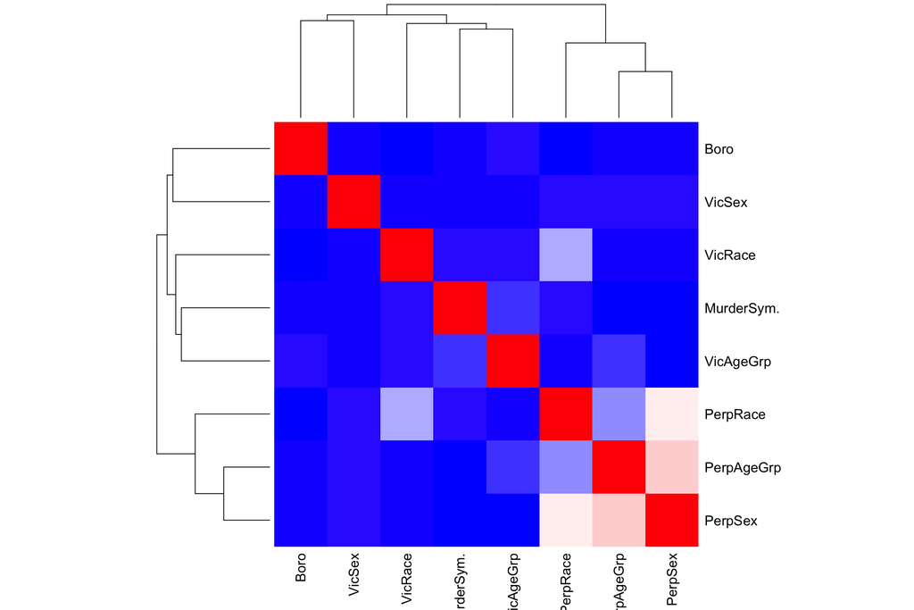

```r
nypd_corr <- select(nypd_df, c("BORO", "STATISTICAL_MURDER_FLAG", "PERP_AGE_GROUP", "PERP_SEX", "PERP_RACE", "VIC_AGE_GROUP", "VIC_SEX", "VIC_RACE",)) #select wanted variables
nypd_corr <- na.omit(nypd_corr) #omit all NA values

nypd_corr$BORO <- factor(nypd_corr$BORO) #factor and make numeric for all variables in nypd_corr
nypd_corr$BORO <- as.numeric(nypd_corr$BORO)

nypd_corr$STATISTICAL_MURDER_FLAG <- factor(nypd_corr$STATISTICAL_MURDER_FLAG)
nypd_corr$STATISTICAL_MURDER_FLAG <- as.numeric(nypd_corr$STATISTICAL_MURDER_FLAG)

nypd_corr$PERP_AGE_GROUP <- factor(nypd_corr$PERP_AGE_GROUP)
nypd_corr$PERP_AGE_GROUP <- as.numeric(nypd_corr$PERP_AGE_GROUP)

nypd_corr$PERP_RACE <- factor(nypd_corr$PERP_RACE)
nypd_corr$PERP_RACE <- as.numeric(nypd_corr$PERP_RACE)

nypd_corr$PERP_SEX <- factor(nypd_corr$PERP_SEX)
nypd_corr$PERP_SEX <- as.numeric(nypd_corr$PERP_SEX)

nypd_corr$VIC_AGE_GROUP <- factor(nypd_corr$VIC_AGE_GROUP)
nypd_corr$VIC_AGE_GROUP <- as.numeric(nypd_corr$VIC_AGE_GROUP)

nypd_corr$VIC_RACE <- factor(nypd_corr$VIC_RACE)
nypd_corr$VIC_RACE <- as.numeric(nypd_corr$VIC_RACE)

nypd_corr$VIC_SEX <- factor(nypd_corr$VIC_SEX)
nypd_corr$VIC_SEX <- as.numeric(nypd_corr$VIC_SEX)

names(nypd_corr) <- c('Boro', 'MurderSym.', 'PerpAgeGrp', 'PerpSex', 'PerpRace', 'VicAgeGrp', 'VicSex', 'VicRace')

nypd_corr_matrix <- cor(nypd_corr)
col<- colorRampPalette(c("blue", "white", "red"))(20)
heatmap(x = nypd_corr_matrix, col = col, symm = TRUE)
```

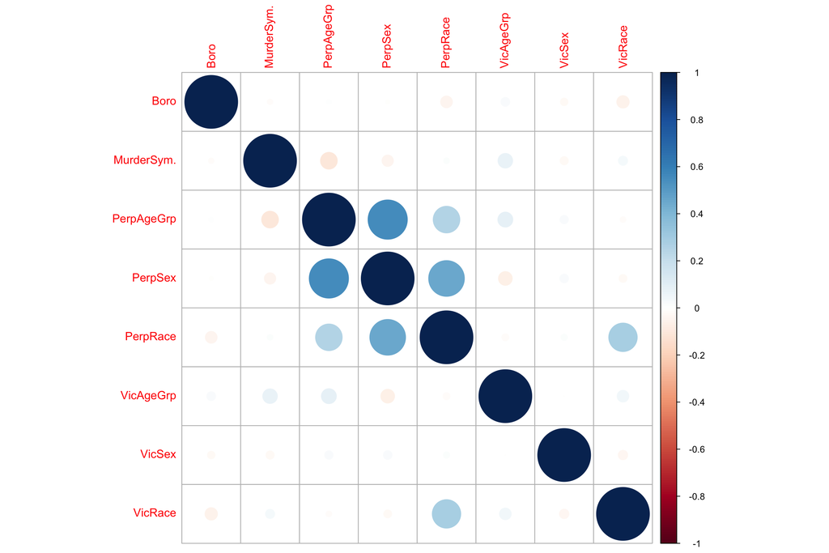

```r
corrplot(nypd_corr_matrix)
```

### Can we predict any perpetrator information based on available victim information?

The previous visualizations show some correlation between victim and perpetrator characteristics (Age Group, Sex, Race). Three linear regression models were created below to understand how these variables are related and how well we can predict information regarding the perpetrator based on the victim’s information. All three models utilize the victim’s sex, age, and race as independent variables. The first model looks to predict the perpetrator’s age group, the second model predicts the sex of the perpetrator, and the final model predicts the race of the perpetrator.

Examining these characteristics is purely for the study of correlation and linear regression. Using any models to predict a person’s race, age, or sex is considered unethical. This becomes especially true if the model making the prediction leads to an arrest, or other life-changing decision, that was unwarranted for someone.

```r
set.seed(123)
train_indices <- sample(nrow(nypd_corr), nrow(nypd_corr)*0.8)

train_data <- nypd_corr[train_indices,] #create training data
test_data <- nypd_corr[-train_indices,] #create testing data
model_age <- lm(PerpAgeGrp ~ VicAgeGrp + VicSex + VicRace, data=train_data) #linear regression model to predict PerpAgeGrp
pred_age <- predict(model_age, newdata=test_data) #predict using above model
mse_age <- mean((test_data$PerpAgeGrp - pred_age)^2) #calculate mse
rmse_age <- sqrt(mse_age) #calculate rmse
rsq_age <- summary(model_age)$r.squared #calculate r-squared
cat("RMSE Age:", rmse_age, "\n")
```

```
## RMSE Age: 2.496538
```

```r
cat("R-squared Age:", rsq_age, "\n")
```

```
## R-squared Age: 0.006997428
```

```r
model_sex <- lm(PerpSex ~ VicAgeGrp + VicSex + VicRace, data=train_data) #linear regression model to predict PerpSex
pred_sex <- predict(model_sex, newdata=test_data) #predict using above model
mse_sex <- mean((test_data$PerpSex- pred_sex)^2) #calculate mse
rmse_sex <- sqrt(mse_sex) #calculate rmse
rsq_sex <- summary(model_sex)$r.squared #calculate r-squared
cat("RMSE Sex:", rmse_sex, "\n")
```

```
## RMSE Sex: 0.493086
```

```r
cat("R-squared Sex:", rsq_sex, "\n")
```

```
## R-squared Sex: 0.005723782
```

```r
model_race <- lm(PerpRace ~ VicAgeGrp + VicSex + VicRace, data=train_data) #linear regression model to predict PerpRage
pred_race <- predict(model_race, newdata=test_data) #predict using above model
mse_race <- mean((test_data$PerpRace- pred_race)^2) #calculate mse
rmse_race <- sqrt(mse_race) #calculate rmse
rsq_race <- summary(model_race)$r.squared #calculate r-squared
cat("RMSE Race:", rmse_race, "\n")
```

```
## RMSE Race: 1.515669
```

```r
cat("R-squared Race:", rsq_race, "\n")
```

```
## R-squared Race: 0.08593425
```

## Conclusions:

#### What borough in NYC has the most shooting incidents?:

- Brooklyn has the most shooting incidents in terms of number of incidents that occur in a year. When examining the number of incidents per borough population, it was found that the Bronx had the most shooting incidents per population per year. The rankings for each of these categories are provided below:
  - Most Total Number of Incidents:
    1. Brooklyn
    2. Bronx
    3. Queens
    4. Manhattan
    5. Staten Island
  - Most Number Incidents Per Population:
    1. Bronx
    2. Brooklyn
    3. Manhattan
    4. Queens
    5. Staten Island

#### How do the variables in the data correlate?:

- There is very little correlation in the data as shown in the visualizations. Some correlation was present in the perpetrator’s information (correlation amongst the perpetrator’s age, sex, and race); however, this correlation was not considered much. Additionally, some correlation was present in the same perpetrator’s characteristics vs. the victim’s same characteristics.

#### Can we predict any perpetrator information based on available victim information?:

- We cannot accurately predict any perpetrator information utilizing a linear regression model. The R-squared values ranged from 0.006 - 0.086 when the initial prediction was run. The perpetrator’s sex had the least success in prediction, while the perpertrator’s race had the most. The RSME values also indicated that the model was not successful. This analysis was conducted based on the need for NYPD, and other police departments, to be able to quickly identify a perpetrator. As mentioned previously, this also presents a significant amount of ethical questions; therefore, the analysis of this should not be considered practical, especially considering the poor results of the model.